# Predicting Disease Spread

```python
import pandas as pd
import numpy as np
from sklearn.model_selection import train_test_split
from sklearn.neighbors import KNeighborsRegressor
import matplotlib.pyplot as plt
import seaborn as sns # for visualiation
from scipy.stats import ttest_ind # t-tests
import altair as alt
alt.renderers.enable('notebook') # enable altair rendering
import statsmodels.formula.api as smf
import statsmodels.api as sm

from IPython.display import HTML

import warnings
warnings.filterwarnings('ignore')
```

Juan Alvarez and Emily Qiao

## Problem Overview

The dengue fever, as the name suggests, is a mosquito-borne disease caused by the dengue viruses. The symptoms of dengue fever include, as listed on [WebMD](https://www.webmd.com/a-to-z-guides/dengue-fever-reference#1-2):

- sudden, high fever
- severe headaches
- pain behind the eyes
- severe joint and muscle pain
- fatigue
- nausea
- vomiting
- skin rash
- mild bleeding

The symptoms are sometimes mild and mistaken for flu. Serious problems can develop, however, if there was lack of early recognition and prompt supportive treatment.

The dengue fever has become a global problem since the 1950s and is now a leading cause of illness and death in the tropics and subtropics. According to [Centers of Disease Control and Prevention (CDC)](https://www.cdc.gov/dengue/index.html), there are not yet any vaccines to prevent dengue fever.

Dengue fever is spread through the bite of female mosquito (Aedes aegypti) when the mosquito takes blood of a infected person and bites a healthy person within a week. Based on information given on [World Health Organization's website](http://www.who.int/denguecontrol/faq/en/index1.html), dengue outbreaks can occur anytime as long as there are mosquitoes alive. Yet regions with high humidity and high temperature usually have more likehood of dengue outbreaks.

In this project, we explore the dengue fever dataset and try to predict the number of dengue cases based on environmental variables. The dataset contains different aspects of data for two cities: San Juan (`sj`) and Iquitos (`iq`). Aside from date indicators (`week_start_date`), NDVI indexes (`ndvi_se`, `ndvi_sw`, `ndvi_ne`, `ndvi_nw`) are also given, which measure the density of vegetation on a patch of land and can be used as an indon icator of agricultural drought. These indexes are relevant because mosquitoes lay eggs in water and the eggs need water to hatch as well. If a region is experiencing emtreme drought, chances of mosquitoes surviving in that area becomes low, hence reducing the spread rate of dengue fever. There is also detailed climate information provided in the dataset, coming from three different sources. `station_max_temp_c`, `station_min_temp_c`, `station_avg_temp_c`, `station_precip_mm`, and `station_diur_temp_rng_c` are measurements from National Ocean and Atmospheric Administration's (NOAA) Global Historical Climatology Network (GHCN) daily climate data weather station, which shows data about *maximum temperature*, *minimun temperature*, *average temperature*, *total precipitation*, and *diurnal temperature range* corresondingly. `precipitation_amt_mm` data is generated by PERSIANN-CDR, an artifical neural network that provides daily rainfall estimates, and represents the total precipitation of a given region at a given time. And finally, the rest of the data come from the NCEP Climate Forecast System Reanalysis (CFSR), which is known for its accuracy of estimation, where `reanalysis_sat_precip_amt_mm` represents *total precipitation*, `reanalysis_dew_point_temp_k` for *mean dew point temperature*, `reanalysis_air_temp_k` for *mean air temperature*, `reanalysis_relative_humidity_percent` for *mean relative humidity*, `reanalysis_specific_humidity_g_per_kg` for *mean specific humidity*, `reanalysis_precip_amt_kg_per_m2` for *total precipitation*, `reanalysis_max_air_temp_k` for *maximum air temperature*, `reanalysis_min_air_temp_k` for *minimum air temperature*, `reanalysis_avg_temp_k` for *average air temperature*, and finally `reanalysis_tdtr_k` for *diurnal temperature range*. Information about temperature, precipitation, and humidity is largely needed because, as explained earlier, mosquitoes live in warm environment and rely on water to lay eggs and hatch. It is very likely to have a positive relationship between warm temperature, high humidity, and more dangue cases reported.

## Data Preparation

### Data Transformation

After we loaded the training data (`dengue_features_train.csv` and `dengue_labels_train`), we combined these two data frames together to create a new data frame with all the environmental features and the total cases of dengue fever. We worked on the combined data frame throughout the project because it has all the information we need and is easier to analyze. **We then divided the new data frame into two small data frames for San Juan and Iquitos, respectively**, because these two cities have very different environmental condition.

### Missing Values

One thing we noticed in the dataset is that under `weekofyear`, there are rows with week 53. This is does not make sense because there are only 52 weeks in a year. Also, all the rows with week 53 have missing values. This make sense because week 53 doesn't exist.

```python
data = pd.read_csv('data/dengue_features_train.csv')
outcome = pd.read_csv('data/dengue_labels_train.csv')
total = data
total['total_cases'] = outcome['total_cases']

total.loc[total.weekofyear == 53]
```

|  | city | year | weekofyear | week_start_date | ndvi_ne | ndvi_nw | ndvi_se | ndvi_sw | precipitation_amt_mm | reanalysis_air_temp_k | ... | reanalysis_relative_humidity_percent | reanalysis_sat_precip_amt_mm | reanalysis_specific_humidity_g_per_kg | reanalysis_tdtr_k | station_avg_temp_c | station_diur_temp_rng_c | station_max_temp_c | station_min_temp_c | station_precip_mm | total_cases |
| --- | --- | --- | --- | --- | --- | --- | --- | --- | --- | --- | --- | --- | --- | --- | --- | --- | --- | --- | --- | --- | --- |
| 139 | sj | 1993 | 53 | 1993-01-01 | NaN | NaN | NaN | NaN | NaN | NaN | ... | NaN | NaN | NaN | NaN | NaN | NaN | NaN | NaN | NaN | 30 |
| 451 | sj | 1999 | 53 | 1999-01-01 | NaN | NaN | NaN | NaN | NaN | NaN | ... | NaN | NaN | NaN | NaN | NaN | NaN | NaN | NaN | NaN | 59 |
| 763 | sj | 2005 | 53 | 2005-01-01 | NaN | NaN | NaN | NaN | NaN | NaN | ... | NaN | NaN | NaN | NaN | NaN | NaN | NaN | NaN | NaN | 10 |
| 1170 | iq | 2005 | 53 | 2005-01-01 | NaN | NaN | NaN | NaN | NaN | NaN | ... | NaN | NaN | NaN | NaN | NaN | NaN | NaN | NaN | NaN | 9 |
| 1430 | iq | 2010 | 53 | 2010-01-01 | NaN | NaN | NaN | NaN | NaN | NaN | ... | NaN | NaN | NaN | NaN | NaN | NaN | NaN | NaN | NaN | 0 |

5 rows × 25 columns

```python
# total = total.loc[total.weekofyear != 53]
total.fillna(method = 'ffill', inplace = True)

sj = total[total.city=='sj']
iq = total[total.city=='iq']
```

## Exploratory Data Analysis

We asked several questions to better understand the dataset.

### What is the distribution of the number of cases of Dengue each week?

Here is the overall distribution of San Juan and Iquitos over the year:

```
[Text(0,0.5,'total cases'), Text(0.5,0,'week of year')]
```

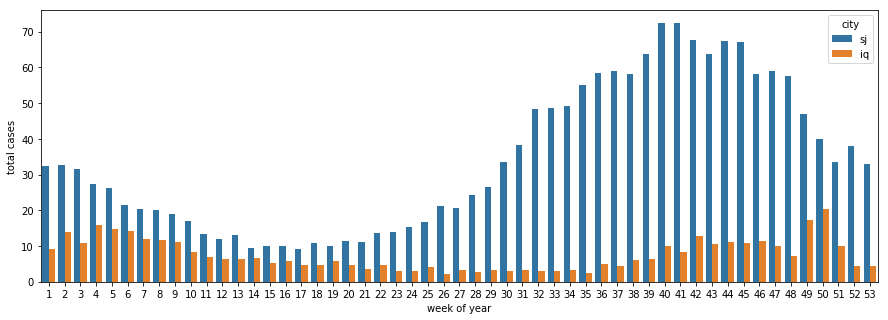

```python
plt.subplots(figsize=(15,5))
g = sns.barplot(x="weekofyear", y="total_cases", hue = "city", data=total, ci = None)
g.set(ylabel='total cases', xlabel = 'week of year')
```

It is very clear that the distribution pattern of the two cities are totally different. In San Juan, dengue cases increase a lot during the second half of the year and go down in the first half of the year. While in Iquitos, the curve looks more flat. The dengue disease is most severe at the end of the year (week 50), and then goes down immediately.

The difference is even more obvious if we align the graphs of the two cities vertically:

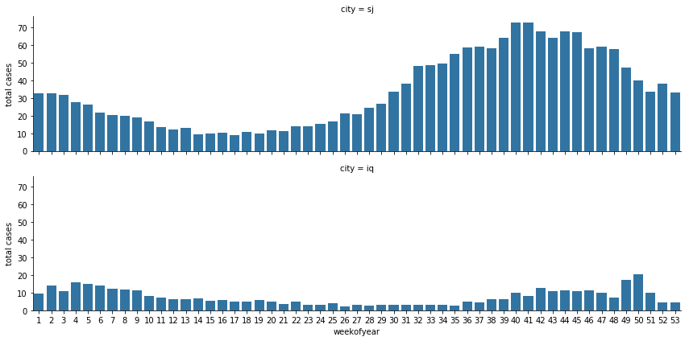

```python
g = sns.FacetGrid(data = total, row="city", aspect=4)
g.map(sns.barplot, "weekofyear", "total_cases", ci=None);
g.set(ylabel='total cases')
```

What made the distrbution of the two cities so different? Interestingly, **San Juan has a tropical monsoon climate**. Rainfall is well-distributed throughout the year, but **January, February, and March are the driest**. This explains why cases of dengue decrease during the first quarter of the year (mosquitoes don't like dry weather) and increase from week 17 (April). On the other hand, **Iquitos has tropical rainforest climate**, where there is constant rainfall throughout the year, **without a distinct dry season**. This is why the curve for Iquitos is a lot more flat.

### How does the number of cases fluctuate over time? Do these temporal relationships persist in both locations?

It turns out that **the number of cases actually fluctuates a lot over time**. In San Juan, there were significantly more cases in 1994 and 1998, while in years like 2000, 2002 and 2008, it seems like dengue fever was pretty under control.

```
[Text(0,0.5,'total cases'), Text(0.5,0,'year'), Text(0.5,1,'San Juan')]
```

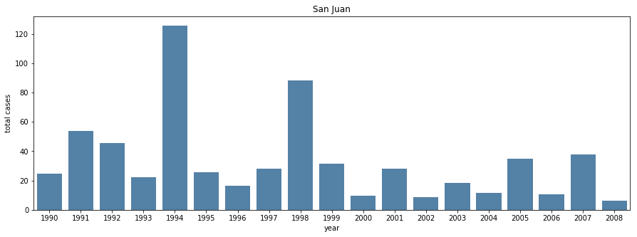

```python
plt.subplots(figsize=(15,5))
g = sns.barplot(x="year", y="total_cases", data=sj, ci = None, color = "steelblue")
g.set(ylabel='total cases', xlabel = 'year', title = "San Juan")
```

And in Iquitos, there was almost no cases of dengue fever before 2002. A outbreak happened in 2002, although the number of cases is still a lot smaller than San Juan's. The disease got controlled in 2003, but became resurgent in 2004. Then there was another outbreak in 2008.

```
[Text(0,0.5,'total cases'), Text(0.5,0,'year'), Text(0.5,1,'Iquitos')]
```

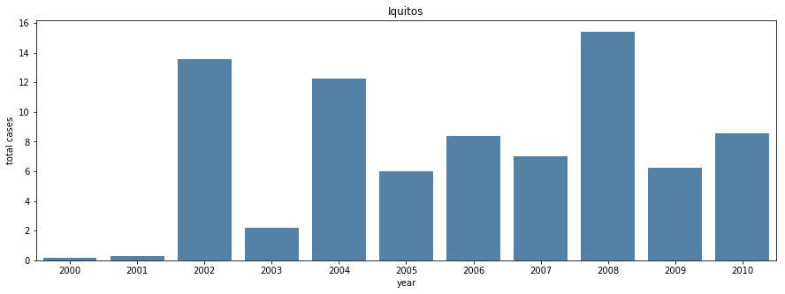

```python
plt.subplots(figsize=(15,5))
g = sns.barplot(x="year", y="total_cases", data=iq, ci = None, color = "steelblue")
g.set(ylabel='total cases', xlabel = 'year', title = "Iquitos")
```

To look at the two graphs together, we can see that the way that **the number of cases of Dengue fever varies is independent of the city** we are looking at. Temporal relationships do not persist in both locations. We see that in Iquitos there was a spike in cases from 2003 to 2004 and 2005 to 2006, but there was a sharp decrease in cases in San Juan.

### Which variables are correlated with your outcome of interest? Are these correlations consistent in both cities?

To figure out what variables might be related to `total_cases`, we made a set of visualizations and compared the distributions.

Here is the distribution **total precipitation** (NOAA's GHCN daily climate data) of each city:

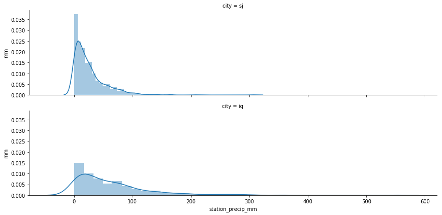

```python
g = sns.FacetGrid(data = total, row="city", aspect=4)
g.map(sns.distplot, "station_precip_mm");
g.set(ylabel='mm')
```

Here is the distribution **maximum temperature** (data from NOAA's GHCN daily climate data weather station) of each city:

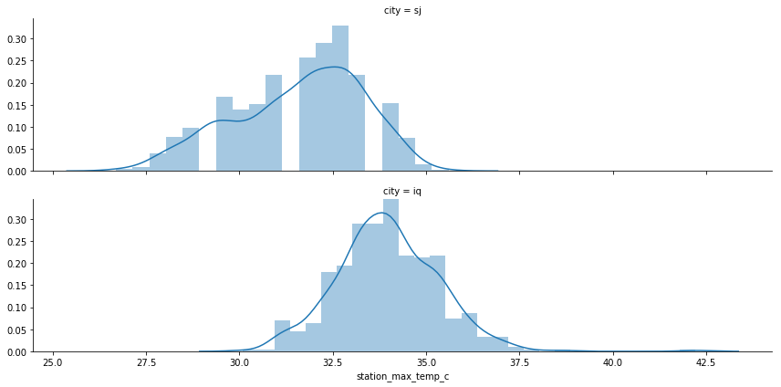

```python
g = sns.FacetGrid(data = total, row="city", aspect=4)
g.map(sns.distplot, "station_max_temp_c");
```

Here is the distribution **minimum air temperature** (data from NOAA's NCEP Climate Forecast System Reanalysis) of each city:

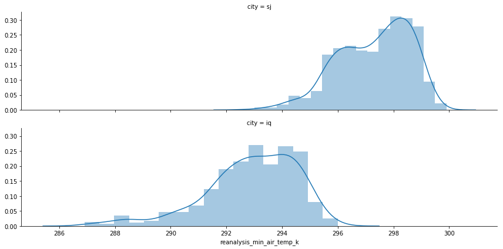

```python
g = sns.FacetGrid(data = total, row="city", aspect=4)
g.map(sns.distplot, "reanalysis_min_air_temp_k");
```

Here is the distribution **mean dew point temperature** (data from NOAA's NCEP Climate Forecast System Reanalysis) of each city:

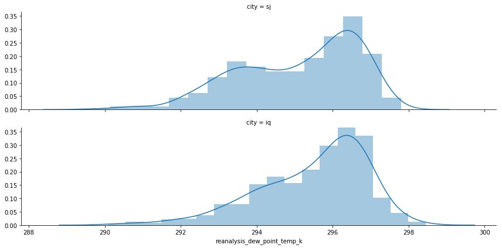

```python
g = sns.FacetGrid(data = total, row="city", aspect=4)
g.map(sns.distplot, "reanalysis_dew_point_temp_k");
```

Here is the distribution **mean relative humidity** (data from NOAA's NCEP Climate Forecast System Reanalysis) of each city:

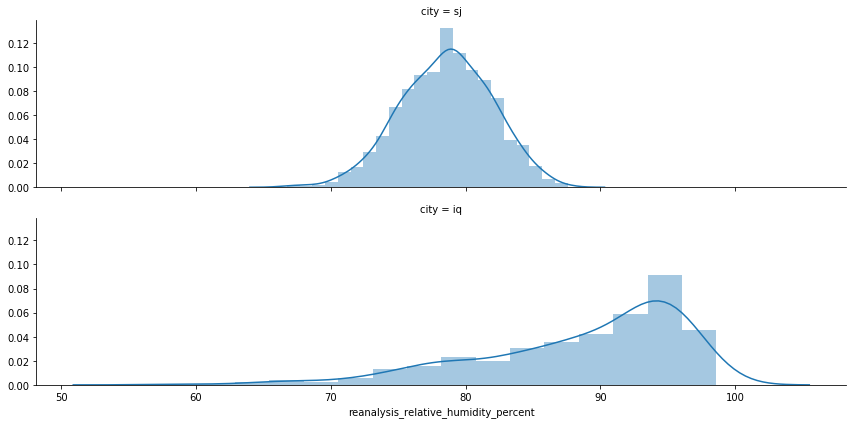

```python
g = sns.FacetGrid(data = total, row="city", aspect=4)
g.map(sns.distplot, "reanalysis_relative_humidity_percent");
```

Looking at each pair of graphs, we were unable to identify any clear linear relation between the enviornment variables and the total casese of dengue fever. As a result, we decided to try some **non-linear model** to predict the total casese of dengue fever.

## Statistical Modeling

```python
var = total.total_cases.var()
mean = total.total_cases.mean()
```

Looking at the previous section about variables correlated to our model and the dataset, we decided that either a Poisson or Negative Binomial Regression model would best fit for our distribution, since our desired outcomes are discrete counts (integers).

To determine which model to use, we first computed the variance of `total_cases`, which is about 1905.6. We then check the mean of `total_cases`, which is only about 24.7.

At this point, it became very clear that the **Negative Binomial Regression** model should be used. The variance is way greater than the mean, which suggests over-dispersion. The negative binomial distribution has one more parameter in its function than the Poisson regression, which adjusts the variance independently from the mean.

### What variables to pick for the model?

Because we were using a Negative Binomial Regression model, we needed to **select the columns where there is overdispersion**. Using a simple for-loop, we filtered out what columns that have larger variances than the means for the data frame of each city.

For San Juan, the columns are:

```python
for column in sj:
    if not (column == 'city' or column == 'week_start_date'):
        if(sj[column].mean() < sj[column].var()):
            print(column)
```

```
weekofyear
precipitation_amt_mm
reanalysis_precip_amt_kg_per_m2
reanalysis_sat_precip_amt_mm
station_precip_mm
total_cases
```

And for Iquitos, the columns are:

```python
for column in iq:
    if not (column == 'city' or column == 'week_start_date'):
        if(iq[column].mean() < iq[column].var()):
            print(column)
```

```
weekofyear
precipitation_amt_mm
reanalysis_precip_amt_kg_per_m2
reanalysis_sat_precip_amt_mm
station_precip_mm
total_cases
```

However, because `total_cases` is our outcome and it doesn't make sense to include `weekofyear`, we excluded these two columns, so the **final list of variables that follow NB distribution for San Juan**:

- station_precip_mm
- precipitation_amt_mm
- reanalysis_sat_precip_amt_mm
- reanalysis_precip_amt_kg_per_m2

the **final list of variables that follow NB distribution for Iquitos**:

- station_precip_mm
- precipitation_amt_mm
- reanalysis_sat_precip_amt_mm
- reanalysis_precip_amt_kg_per_m2

Interetingly enough, **all of these variables are related to total precipitation**. But it also makes sense because mosquitoes love water. We then looked at the distribution of each variable:

**station_precip_mm** from NOAA's GHCN daily climate data:

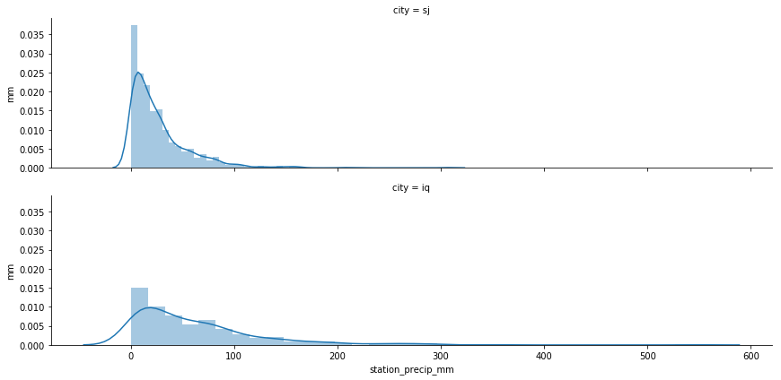

```python
g = sns.FacetGrid(data = total, row="city", aspect=4)
g.map(sns.distplot, "station_precip_mm");
g.set(ylabel='mm')
```

**precipitation_amt_mm** from PERSIANN satellite data:

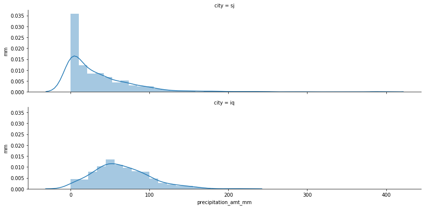

```python
g = sns.FacetGrid(data = total, row="city", aspect=4)
g.map(sns.distplot, "precipitation_amt_mm");
g.set(ylabel='mm')
```

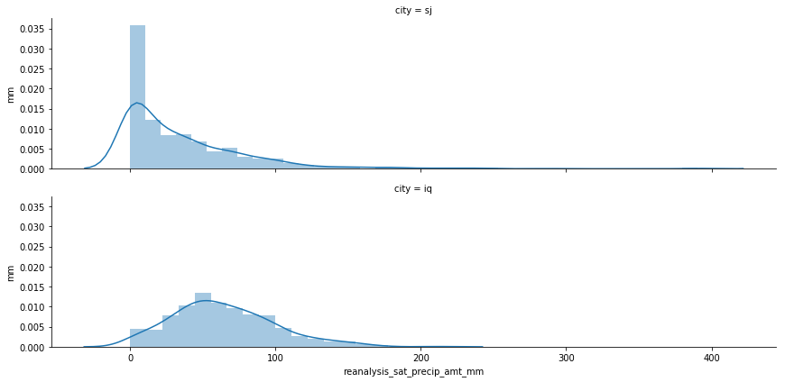

```python
g = sns.FacetGrid(data = total, row="city", aspect=4)
g.map(sns.distplot, "reanalysis_sat_precip_amt_mm");
g.set(ylabel='mm')
```

**reanalysis_precip_amt_kg_per_m2** from NOAA's NCEP Climate Forecast System Reanalysis

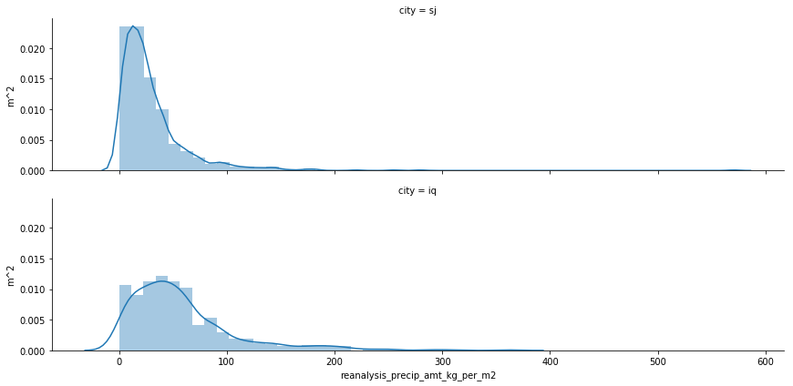

```python
g = sns.FacetGrid(data = total, row="city", aspect=4)
g.map(sns.distplot, "reanalysis_precip_amt_kg_per_m2");
g.set(ylabel='m^2')
```

Comparing the graphs above with the standard graph of negative binomial distribution,

[figure not shown]

We noticed that actually **only the graph for reanalysis_precip_amt_kg_per_m2 follows a negative binomial distribution** based on the look of the distributions.

Therefore in our model, only `reanalysis_precip_amt_kg_per_m2` is included in the formula. This is reasonable because all the other variables are pertaining to the precipitation, if we include multiple of them, the model will generate high p values because of this redundancy.

### Our Models

We then created models for the San Juan data frame and Iquitos data frame correspondingly.

```python
sj_model = smf.glm(formula='total_cases ~ reanalysis_precip_amt_kg_per_m2', data=sj, family=sm.families.NegativeBinomial()).fit()
iq_model = smf.glm(formula='total_cases ~ reanalysis_precip_amt_kg_per_m2', data=iq, family=sm.families.NegativeBinomial()).fit()
sj['sj_predictions'] = sj_model.predict()
iq['iq_predictions'] = iq_model.predict()
```

Here is the **Generalized Linear Model Regression Results of our model for San Juan**:

```python
print(sj_model.summary())
```

```
                 Generalized Linear Model Regression Results
==============================================================================
Dep. Variable:            total_cases   No. Observations:                  936
Model:                            GLM   Df Residuals:                      934
Model Family:        NegativeBinomial   Df Model:                            1
Link Function:                    log   Scale:                          1.0000
Method:                          IRLS   Log-Likelihood:                -4240.8
Date:                Tue, 13 Nov 2018   Deviance:                       1075.8
Time:                        03:28:28   Pearson chi2:                 2.00e+03
No. Iterations:                    13   Covariance Type:             nonrobust
===================================================================================================
                                      coef    std err          z      P>|z|      [0.025      0.975]
---------------------------------------------------------------------------------------------------
Intercept                           3.3294      0.044     76.313      0.000       3.244       3.415
reanalysis_precip_amt_kg_per_m2     0.0061      0.001      6.614      0.000       0.004       0.008
===================================================================================================
```

Here is the **Generalized Linear Model Regression Results of our model for Iquitos**:

```python
print(iq_model.summary())
```

```
                 Generalized Linear Model Regression Results
==============================================================================
Dep. Variable:            total_cases   No. Observations:                  520
Model:                            GLM   Df Residuals:                      518
Model Family:        NegativeBinomial   Df Model:                            1
Link Function:                    log   Scale:                          1.0000
Method:                          IRLS   Log-Likelihood:                -1599.2
Date:                Tue, 13 Nov 2018   Deviance:                       775.04
Time:                        03:28:29   Pearson chi2:                     896.
No. Iterations:                    10   Covariance Type:             nonrobust
===================================================================================================
                                      coef    std err          z      P>|z|      [0.025      0.975]
---------------------------------------------------------------------------------------------------
Intercept                           1.7908      0.071     25.141      0.000       1.651       1.930
reanalysis_precip_amt_kg_per_m2     0.0038      0.001      4.157      0.000       0.002       0.006
===================================================================================================
```

Because the p-values of the precipitation variable for both models are below 0.05, we can reject the null hypothesis and say that there is a significant correlation between *total_cases* and *reanalysis_precip_amt_kg_per_m2*.

### Making Predictions

We evaluated our model by making predictions about the total cases of denge fever.

Here is the result of the San Juan model:

```
Text(0.5,1,"Predictions made by San Juan's model VS actual dengue cases in San Juan")
```

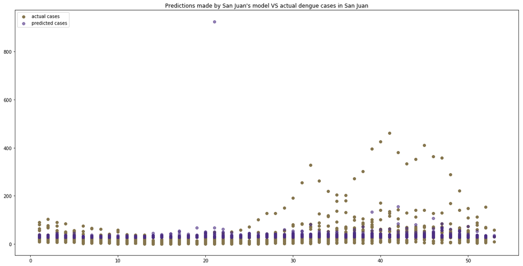

```python
plt.figure(figsize=(20,10))
plt.scatter(x=sj['weekofyear'], y=sj['total_cases'], c="#85754d", label="actual cases")
plt.scatter(x=sj['weekofyear'], y=sj['sj_predictions'], c="#4b2e83", label="predicted cases", alpha = 0.6)
plt.legend(loc='upper left')
plt.title("Predictions made by San Juan's model VS actual dengue cases in San Juan")
```

Here is the result of the Iquitos model:

```
Text(0.5,1,"predictions made by Iquitos' model VS actual dengue cases in Iquitos")
```

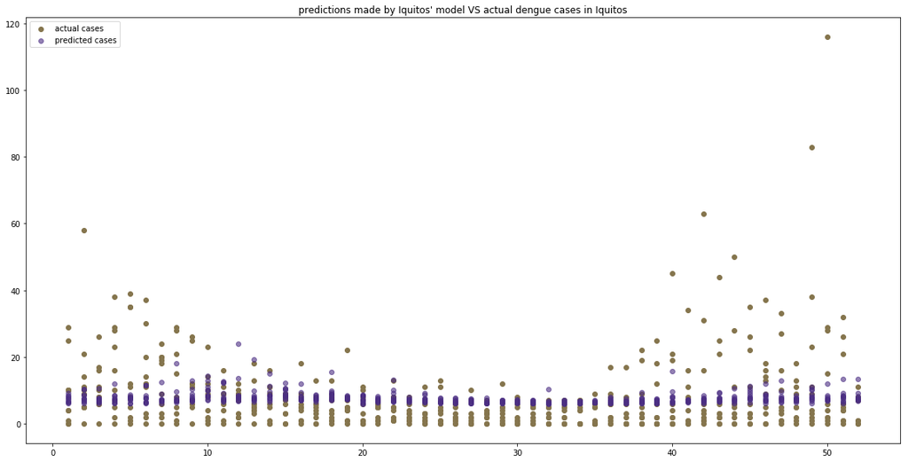

```python
plt.figure(figsize=(20,10))
plt.scatter(x=iq['weekofyear'], y=iq['total_cases'], c="#85754d", label="actual cases")
plt.scatter(x=iq['weekofyear'], y=iq['iq_predictions'], c="#4b2e83", label="predicted cases", alpha = 0.6)
plt.legend(loc='upper left')
plt.title("predictions made by Iquitos' model VS actual dengue cases in Iquitos")
```

```python
HTML('''<script>
code_show=true;
function code_toggle() {
 if (code_show){
 $('div.input').hide();
 } else {
 $('div.input').show();
 }
 code_show = !code_show
}
$( document ).ready(code_toggle);
</script>
The raw code for this IPython notebook is by default hidden for easier reading.
To toggle on/off the raw code, click <a href="javascript:code_toggle()">here</a>.''')
```